# Emory_TicksABM_Challenge

David Civetello, Lynda Bradley, KM Barnett, Aniruddha Belsare

### NEON Ecological Forecasting Challenge Webpage:

https://ecoforecast.org/efi-rcn-forecast-challenges/

To forecast total *Ixodes scapularis* and *Amblyomma americanum* nymphs each epidemiological week (Sun-Sat) at a set of NEON plots within NEON sites.

### Important dates for the forecasting challenge

Training data available until Jan 31, 2021  
1st Forecast submission March 31, 2021

#### Link to Github repository neonfprecast-ticks:

https://github.com/eco4cast/neon4cast-ticks

#### Eleven tips for working with large data sets:

https://www.nature.com/articles/d41586-020-00062-z

#### RMarkdown resources:

https://m-clark.github.io/Introduction-to-Rmarkdown/

https://rmd4sci.njtierney.com/ https://bookdown.org/yihui/rmarkdown/ https://www.rosannavanhespen.nl/thesis_in_rmarkdown/ https://rmarkdown.rstudio.com/formats.html

#### Github & R:

https://lab.github.com/ https://dev.to/lberlin/a-github-guide-for-people-who-don-t-understand-github-n50 https://ropenscilabs.github.io/actions_sandbox/

#### Version control:

https://www.britishecologicalsociety.org/wp-content/uploads/2019/06/BES-Guide-Reproducible-Code-2019.pdf

https://happygitwithr.com/ https://www.r-bloggers.com/2018/05/using-rstudio-and-git-version-control/ https://www.edureka.co/blog/git-tutorial/

This is the best: https://github.com/pcottle/learnGitBranching

#### NetLogo

Style guide http://ccl.northwestern.edu/courses/mam-03/styleguide.html

Avoid globals https://gist.github.com/nicolaspayette/8051fa9c289897c4bf97c4d6abf3386d

### ODD: Multi-stage ticks, multihost agent-based model

**Purpose**  
MSTMH is an agent-based model of an ecological community comprising of *Ixodes scapularis* (blacklegged tick) and three vertebrate hosts, white-footed mice *Peromyscus leucopus*, white-tailed deer *Odocoileus virginianus* and domestic cattle *Bos taurus*. The objective is to simulate the population dynamics of *I. scapularis*, and assess effects of grazing domestic ruminants on abundance of different stages of *I. scapularis*. Our overarching goal is to explore the complex dynamics of host community composition, tick stages and *Borrelia burgdorferi*, and thereby support development of locale specific Lyme disease control strategies.  
**Entities, state variables and scales**  
*Spatial scale*: MSTMH has a 400 meters by 400 meters (16 hectares) simplified landscape. Each patch is 25 m^2.  
*Temporal scale*: MSTMH has a weekly timestep, and the duration of the simulation is 20 years. First 5 years are for equilibration.  
*Entities*: This model has seven entities: four tick stages (egg, larval, nymphal and adult) and three host species - white-footed mouse, white-tailed deer and domestic cattle.  
*State variables*: The larval (**lticks**) and nymphal (**nticks**) stages have six state variables each: *aiw* (age in weeks), *loc* (location: patch id or host id), *hs?* (boolean: true if seeking host), *fe?* (boolean: true if fully engorged), *toh* (time attached to the current host) and *moltp* (counter for time since fully engorged). The adult (**aticks**) stage has the same state variables as the other two stages with the exception of *moltp*. Instead it has a state variable *rpot* (reproductive potential - number of eggs produced). The egg stage does not have any state variables.  
Mice in the model have three state variables: *home-patch*, *hrr* (home-range radius) and *tc* (tick carrying capacity). Other host species, deer and cattle, have only one state variable, *tc*.  
**Process overview and scheduling**

*Mice population dynamics*: Mice are randomly distributed in the model landscape. We do not simulate births and deaths in the model mice population. Instead, mice density, and therefore mice population, is set to fluctuate quarterly. A random value between 25 and 35 is selected every four months to set the density of mice per hectare. (Reference / supporting literature?).

Each mouse has a home-patch and a home-range. The home-range is set between 0.1 hectare (1000 m^2) and 1.6 hectare (16000 m^2) (Reference?).Every time step, each mouse accesses upto seven random patches within its homerange.

###### Figure 1: Tick stages and hosts

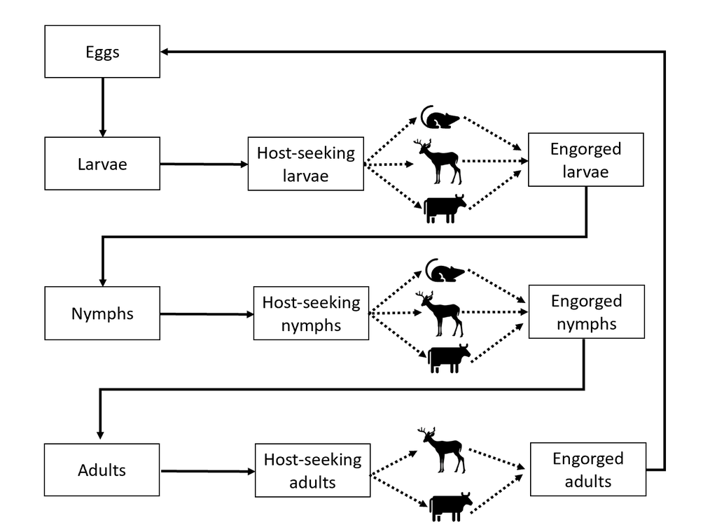

The larval and nymphal peak activity periods do not overlap.

Almost without exception, macroparasites are aggregated across their host populations - majority of the parasite population is concentrated into a minority of the host population. Devevey_2012 report that most larvae (79.6 %) and most nymphs (79.8 %) at their study sites in southeastern Pennsylvanis were attached to a minority of mice (46.9 % and 25.4 % for larval and nymphal stages, respectively). The distribution of ticks on mice follows a negative binomial distribution (larval distribution, k = 0?862,P = 0?84; nymphal distribution, k = 0?299, P = 0?14) that strongly supports a non-random distribution. Heterogeneity among individual hosts explains the aggregation of ectoparasites-supported by repeatability of ticks on mice over time such that highly parasitized mice remain highly parsitized throughout the season. Majority of ticks parasitized a consistent set of mice throughout the activity seasons. Also, the entire cohort of ticks feeding on a mouse is replaced every 3-5 days (Brunner et al. 2011)

###### Figure 2: From Devevey & Brisson, 2012 - larval aggregation

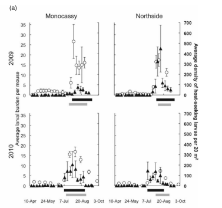

###### Figure 3: From Devevey & Brisson, 2012 - nymphal aggregation

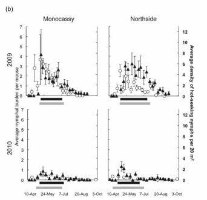

Figure 3

https://www.nytimes.com/2017/08/02/science/ticks-lyme-disease-foxes-martens.html?mwrsm=Email

#### Notes and references

*I. scapularis* crawls no more than a few meters during any of its life stages (Daniels and Fish 1990,Falco and Fish 1991, Daniels et al. 1996).

*I. scapularis* is a three-host tick, each postembryonic life stage (larva, nymph, and adult) requires a single blood meal to molt to the next life stage (Sonenshine 1991).

Devevey_2012 https://www.ncbi.nlm.nih.gov/pmc/articles/PMC3856707/ Authors have examined the aggregation of immature *I. scapularis* ticks (larvae and nymphs) both while seeking a host and while attached to white-footed mice.